# What qualities make Novak Djokovic so dominant at tennis?

In the year 2021, Novak Djokovic has dominated the ATP tour, winning the first three grand slams to equal his career rivals, Rafael Nadal and Roger Federer at 20 grand slams each. In this document, we will examine attributes in Novak Djokovic's game by utilization of "The Data Science Pipeline". This pipeline is comprised of 5 stages: 1. Data Collection, 2. Data Management, 3. Exploratory Data Analysis, 4. Machine Learning, and 5. Communication of Insights Attained.

# Section 1: Data Collection

```python
import datetime
import pandas as pd
import requests as req
from bs4 import BeautifulSoup
import datetime
import numpy as np
import matplotlib.pyplot as plt
import seaborn as sns
from sklearn import linear_model
from sklearn.metrics import r2_score
from scipy import stats


pd.set_option('display.max_columns', None)

data1 = pd.read_csv("tennis.tsv", sep='\t')
data2 = pd.read_csv("tennis2.tsv", sep='\t')
data3 = pd.read_csv("tennis3.tsv", sep='\t')
data4 = pd.read_csv("tennis4.tsv", sep='\t')

df = data1.merge(data2)
df = df.merge(data3)
df.head()
```

|  | Rk | Player | M | M W-L | M W% | SPW | SPW-InP | Aces | Ace% | DFs | DF% | DF/2s | 1stIn | 1st% | 2nd% | 2%-InP | Hld% | Pts/SG | PtsL/SG | RPW | RPW-InP | vAce% | vDF% | v1st% | v2nd% | Brk% | Pts/RG | PtsW/RG | MdOppRk | … |
| --- | --- | --- | --- | --- | --- | --- | --- | --- | --- | --- | --- | --- | --- | --- | --- | --- | --- | --- | --- | --- | --- | --- | --- | --- | --- | --- | --- | --- | --- | --- |
| 0 | 1 | Novak Djokovic [SRB] | 65 | 57-8 | 87.70% | 67.40% | 67.20% | 425 | 7.70% | 192 | 3.50% | 9.80% | 64.30% | 74.90% | 53.80% | 59.60% | 85.90% | 6.2 | 2.0 | 43.40% | 44.40% | 6.60% | 3.60% | 36.00% | 55.60% | 34.20% | 6.8 | 3.0 | 31.0 | … |
| 1 | 2 | Daniil Medvedev [RUS] | 63 | 49-14 | 77.80% | 68.80% | 67.40% | 580 | 12.20% | 184 | 3.90% | 10.00% | 61.40% | 79.00% | 52.50% | 58.40% | 87.10% | 5.9 | 1.8 | 40.90% | 41.00% | 5.00% | 3.20% | 32.20% | 55.60% | 28.90% | 6.6 | 2.7 | 37.0 | … |
| 2 | 3 | Rafael Nadal [ESP] | 45 | 37-8 | 82.20% | 66.80% | 67.20% | 166 | 4.80% | 99 | 2.80% | 7.90% | 64.10% | 72.90% | 56.10% | 60.90% | 85.10% | 6.1 | 2.0 | 43.50% | 44.50% | 6.60% | 3.50% | 35.60% | 56.70% | 36.30% | 6.4 | 2.8 | 18.0 | … |
| 3 | 4 | Stefanos Tsitsipas [GRE] | 76 | 56-20 | 73.70% | 68.60% | 67.70% | 491 | 8.00% | 158 | 2.60% | 7.30% | 64.40% | 74.90% | 57.10% | 61.50% | 87.20% | 6.1 | 1.9 | 38.30% | 38.40% | 5.50% | 3.40% | 30.80% | 51.40% | 24.80% | 6.4 | 2.5 | 32.0 | … |
| 4 | 5 | Alexander Zverev [GER] | 66 | 49-17 | 74.20% | 67.10% | 67.40% | 683 | 11.90% | 352 | 6.10% | 18.20% | 66.30% | 76.80% | 48.10% | 58.80% | 83.50% | 6.1 | 2.0 | 40.30% | 39.90% | 4.60% | 3.80% | 33.60% | 51.90% | 28.80% | 6.7 | 2.7 | 42.0 | … |

The columns for the datset above are described below:

Column Name: Meaning

Rk: Player Rank  
Player: Player Name M: Matches Played  
M W-L: Match Win-Loss Record  
M W%: Match Win Percentage  
SPW: Percentage of Service Points Won  
SPW-InP:  
Aces: Number of Aces  
Ace%: Ace Rate DFs: Number of Double Faults  
DF%: Double Fault Rate  
DF/2s: Double Faults per Second Serve  
1stIn: First Serve In Percentage  
1st%: First Serve Points Win Percentage 2nd%: Second Serve Points Win Percentage  
2%-InP:  
Hld%: Hold Rate, Percentage of Service Games Won  
Pts/SG: Points Played per Service Game  
PtsL/SG: Points Lost per Service Game  
RPW: Percentage of Return Points Won  
RPW-InP:  
vAce%: Ace Rate Against vDF%: Double Fault Rate Against v1st%: First Serve Return Win Percentage  
v2nd%: Second Serve Return Win Percentage  
Brk%: Return Games Win Percentage  
Pts/RG: Points Played per Return Game  
PtsW/RG: Points Won per Return Game MdOppRk: Median Opponent Rank  
MnOppRk: Mean Opponent Rank BPConv%: Percentage of Break Point Opportunities Converted  
BPConv: Break Points Opportunities Converted  
BPChnc: Break Point Chances BP/G: Break Point Chances per Game  
BP/S: Break Point Chances per Set  
BP/M: Break Point Chances per Match Bks/S: Return Games Won per Set Bks/M: Return Games Won per Match  
BPSvd%: Percentage of Break Point Saved while Serving  
BPSaved: Break Points Saved while Serving  
BPvs: Break Points Faced  
BPvs/G: Break Points Faced per Game BPvs/S: Break Points Faced per Set  
BPvs/M: Break Points Faced per Match  
Bkn/S: Service Games Lost per Set  
Bkn/M: Service Games Lost per Match

# Section 2: Data Management

The data obtained from the TSV file is fairly tidy but there are some changes we have to make before we can effectively run analysis on the data. First, the percentage signs that occur in elements of some columns need to be removed, because otherwise these columns will not be able to be used. Second, these same elements from columns with percentage signs are currently string values and need to be changed to be float values. There is fortunately no missing data.

```python
df['M W%'] = df['M W%'].map(lambda x: x.rstrip('%'))
df['SPW'] = df['SPW'].map(lambda x: x.rstrip('%'))
df['SPW-InP'] = df['SPW-InP'].map(lambda x: x.rstrip('%'))
df['Ace%'] = df['Ace%'].map(lambda x: x.rstrip('%'))
df['DF%'] = df['DF%'].map(lambda x: x.rstrip('%'))
df['DF/2s'] = df['DF/2s'].map(lambda x: x.rstrip('%'))
df['1stIn'] = df['1stIn'].map(lambda x: x.rstrip('%'))
df['1st%'] = df['1st%'].map(lambda x: x.rstrip('%'))
df['2nd%'] = df['2nd%'].map(lambda x: x.rstrip('%'))
df['2%-InP'] = df['2%-InP'].map(lambda x: x.rstrip('%'))
df['Hld%'] = df['Hld%'].map(lambda x: x.rstrip('%'))
df['RPW'] = df['RPW'].map(lambda x: x.rstrip('%'))
df['RPW-InP'] = df['RPW-InP'].map(lambda x: x.rstrip('%'))
df['vAce%'] = df['vAce%'].map(lambda x: x.rstrip('%'))
df['vDF%'] = df['vDF%'].map(lambda x: x.rstrip('%'))
df['v1st%'] = df['v1st%'].map(lambda x: x.rstrip('%'))
df['v2nd%'] = df['v2nd%'].map(lambda x: x.rstrip('%'))
df['Brk%'] = df['Brk%'].map(lambda x: x.rstrip('%'))
df['BPConv%'] = df['BPConv%'].map(lambda x: x.rstrip('%'))
df['BPSvd%'] = df['BPSvd%'].map(lambda x: x.rstrip('%'))

df['M W%'] = pd.to_numeric(df['M W%'])
df['SPW'] = pd.to_numeric(df['SPW'])
df['SPW-InP'] = pd.to_numeric(df['SPW-InP'])
df['Ace%'] = pd.to_numeric(df['Ace%'])
df['DF%'] = pd.to_numeric(df['DF%'])
df['DF/2s'] = pd.to_numeric(df['DF/2s'])
df['1stIn'] = pd.to_numeric(df['1stIn'])
df['1st%'] = pd.to_numeric(df['1st%'])
df['2nd%'] = pd.to_numeric(df['2nd%'])
df['2%-InP'] = pd.to_numeric(df['2%-InP'])
df['Hld%'] = pd.to_numeric(df['Hld%'])
df['RPW'] = pd.to_numeric(df['RPW'])
df['RPW-InP'] = pd.to_numeric(df['RPW-InP'])
df['vAce%'] = pd.to_numeric(df['vAce%'])
df['vDF%'] = pd.to_numeric(df['vDF%'])
df['v1st%'] = pd.to_numeric(df['v1st%'])
df['v2nd%'] = pd.to_numeric(df['v2nd%'])
df['Brk%'] = pd.to_numeric(df['Brk%'])
df['BPConv%'] = pd.to_numeric(df['BPConv%'])
df['BPSvd%'] = pd.to_numeric(df['BPSvd%'])

df.head()
```

|  | Rk | Player | M | M W-L | M W% | SPW | SPW-InP | Aces | Ace% | DFs | DF% | DF/2s | 1stIn | 1st% | 2nd% | 2%-InP | Hld% | Pts/SG | PtsL/SG | RPW | RPW-InP | vAce% | vDF% | v1st% | v2nd% | Brk% | Pts/RG | PtsW/RG | MdOppRk | … |
| --- | --- | --- | --- | --- | --- | --- | --- | --- | --- | --- | --- | --- | --- | --- | --- | --- | --- | --- | --- | --- | --- | --- | --- | --- | --- | --- | --- | --- | --- | --- |
| 0 | 1 | Novak Djokovic [SRB] | 65 | 57-8 | 87.7 | 67.4 | 67.2 | 425 | 7.7 | 192 | 3.5 | 9.8 | 64.3 | 74.9 | 53.8 | 59.6 | 85.9 | 6.2 | 2.0 | 43.4 | 44.4 | 6.6 | 3.6 | 36.0 | 55.6 | 34.2 | 6.8 | 3.0 | 31.0 | … |
| 1 | 2 | Daniil Medvedev [RUS] | 63 | 49-14 | 77.8 | 68.8 | 67.4 | 580 | 12.2 | 184 | 3.9 | 10.0 | 61.4 | 79.0 | 52.5 | 58.4 | 87.1 | 5.9 | 1.8 | 40.9 | 41.0 | 5.0 | 3.2 | 32.2 | 55.6 | 28.9 | 6.6 | 2.7 | 37.0 | … |
| 2 | 3 | Rafael Nadal [ESP] | 45 | 37-8 | 82.2 | 66.8 | 67.2 | 166 | 4.8 | 99 | 2.8 | 7.9 | 64.1 | 72.9 | 56.1 | 60.9 | 85.1 | 6.1 | 2.0 | 43.5 | 44.5 | 6.6 | 3.5 | 35.6 | 56.7 | 36.3 | 6.4 | 2.8 | 18.0 | … |
| 3 | 4 | Stefanos Tsitsipas [GRE] | 76 | 56-20 | 73.7 | 68.6 | 67.7 | 491 | 8.0 | 158 | 2.6 | 7.3 | 64.4 | 74.9 | 57.1 | 61.5 | 87.2 | 6.1 | 1.9 | 38.3 | 38.4 | 5.5 | 3.4 | 30.8 | 51.4 | 24.8 | 6.4 | 2.5 | 32.0 | … |
| 4 | 5 | Alexander Zverev [GER] | 66 | 49-17 | 74.2 | 67.1 | 67.4 | 683 | 11.9 | 352 | 6.1 | 18.2 | 66.3 | 76.8 | 48.1 | 58.8 | 83.5 | 6.1 | 2.0 | 40.3 | 39.9 | 4.6 | 3.8 | 33.6 | 51.9 | 28.8 | 6.7 | 2.7 | 42.0 | … |

# Section 3: Exploratory Data Analysis

In our dataframe, the column named M W% stands for match winning percentage. Since winning matches is the outcome that makes Novak Djokovic so successful, it can be viewed as our dependent variable. We are going to create a correlation matrix between the columns of the dataframe, and will examine specifically how the different columns correlate with match winning percentage. The correlation matrix is displayed using Seaborn, a useful statistical data visualization library, via the heatmap function.

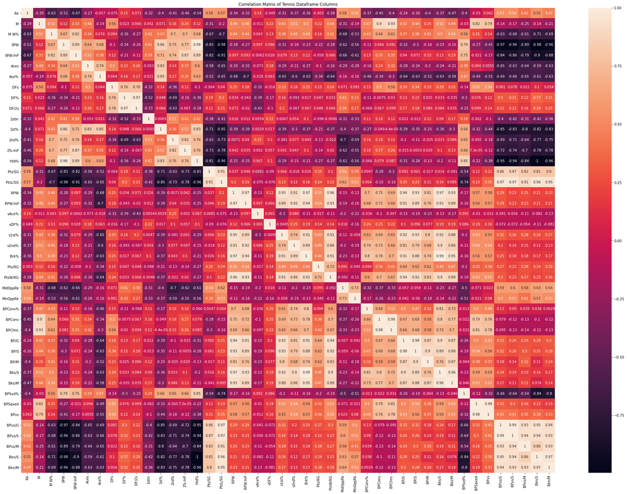

```python
plt.subplots(figsize = (35,25))
hm = sns.heatmap(df.corr(), annot = True)
hm.set_title("Correlation Matrix of Tennis Dataframe Columns")
```

The heat map above shows the correlation coefficients between all column variables in the tennis dataframe. This coefficient, named the r value, ranges from [-1,1] which 0 to 1 is measuring how strongly positively correlated the two variables are, and 0 to -1 is measuring how strongly negatively correlated the two variables are. Correlation coefficients between 0.0 and 0.3 have a weak or no correlation, between 0.3 and 0.5 have a weak-moderate correlation, between 0.5-0.7 have a moderate correlation, and between 0.7-1.0 have a strong correlation. We will examine variables that have a correlation greater than 0.5 with match winning percentage, M W%. These variables are listed below, along with their respective correlation coefficients with match winning percentage. Some variables that have a moderate or high correlation with match winning percentage were removed due to a duplicate nature. For instance Bks/S: Return Games Won per Set was used so Bks/M: Return Games Won per Match was removed.

# M, Matches Played: 0.51

SPW, Percentage of Service Points Won: 0.67  
2nd%, Second Serve Points Win Percentage: 0.70  
Hld%, Hold Rate, Percentage of Service Games Won: 0.68  
Pts/SG, Points Played per Service Game: -0.67  
PtsL/SG, Points Lost per Service Game: -0.70  
BPConv, Break Points Opportunities Converted: 0.64  
BPChnc, Break Point Chances: 0.61  
Bks/S: Return Games Won per Set: 0.5  
BPSvd%: Percentage of Break Point Saved while Serving: 0.56  
BPvs/G: Break Points Faced per Game: -0.63  
Bkn/S: Service Games Lost per Set: -0.71

# Section 4: Machine Learning

In this section we are going to use machine learning to find the linear regressions between match winning percentage and the various predictor variables it is moderately to highly correlated with, listed above. An important aspect of data science and the data science pipeline is understanding how to leverage helpful libraries in order to accomplish desired tasks. In this section we are going to use sklearn, a machine learning library, in order to find these linear regressions. The function used to create a linear regression model is sklearn's linear_model.LinearRegression() and that model can be fit with columns from the tennis dataframe to create the linear regression. It is highly recommended that the reader look into documentation for sklearn if they are curious about its capabilities and other machine learning tasks that sklearn can accomplish. A critical aspect of data science is being comfortable with documentation and it is an extremely helpful resource! https://scikit-learn.org/stable/user_guide.html  
Additionally we'll be using another data visualization library named matplotlib, in order to create scatter plots and their respective linear regressions for plots Match Winning percentage vs "Predictor Variable X" where variable X is the correlated variable.  
We are hypothesizing that match win percentage is correlated with each predictor variable. This creates a hypothesis and respective null hypothesis for match win percentage and each predictor variable, with the null hypothesis being that matching win percentage is not correlated with predictor variable X. The p value for each linear regression will help us decide if we can reject the null hypothesis.

```
The R squared value is: 0.4521908466934156
The p value is: 8.882330089399635e-08
```

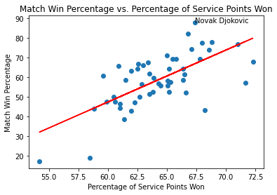

```python
winPerc = df['M W%'].to_numpy()
SPW = df['SPW'].to_numpy().reshape((-1,1))

lm = linear_model.LinearRegression()
lm.fit(SPW, winPerc)
fig3, ax3, = plt.subplots()

ax3.scatter(SPW, winPerc)
ax3.plot(SPW, lm.predict(SPW), color='red')
ax3.set(xlabel="Percentage of Service Points Won", ylabel="Match Win Percentage", title="Match Win Percentage vs. Percentage of Service Points Won")

novakDF = df[df['Player'] == "Novak Djokovic [SRB]"]
novakX = df['SPW'][0]
novakMWP = novakDF['M W%'][0]
plt.text(novakX, novakMWP, "Novak Djokovic")

rSquared = r2_score(winPerc, lm.predict(SPW))
slope, intercept, r_value, p_value, std_err = stats.linregress(df['SPW'].to_numpy(), winPerc)

print("The R squared value is: " +str(rSquared))
print("The p value is: " +str(p_value))
```

```
The R squared value is: 0.25711741003324806
The p value is: 0.00017130290520692268
```

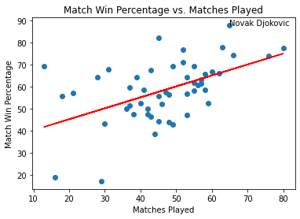

```python
matches = df['M'].to_numpy().reshape((-1,1))

lm = linear_model.LinearRegression()
lm.fit(matches, winPerc)
fig3, ax3, = plt.subplots()

ax3.scatter(matches, winPerc)
ax3.plot(matches, lm.predict(matches), color='red')
ax3.set(xlabel="Matches Played", ylabel="Match Win Percentage", title="Match Win Percentage vs. Matches Played")

novakX = df['M'][0]
plt.text(novakX, novakMWP, "Novak Djokovic")

rSquared = r2_score(winPerc, lm.predict(matches))
slope, intercept, r_value, p_value, std_err = stats.linregress(df['M'].to_numpy(), winPerc)

print("The R squared value is: " +str(rSquared))
print("The p value is: " +str(p_value))
```

```
The R squared value is: 0.4915567427762051
The p value is: 1.427291663310317e-08
```

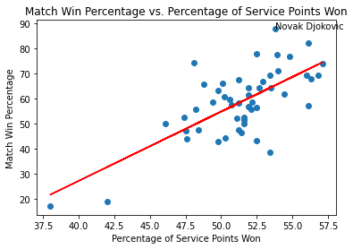

```python
secondSPW = df['2nd%'].to_numpy().reshape((-1,1))

lm = linear_model.LinearRegression()
lm.fit(secondSPW, winPerc)
fig3, ax3, = plt.subplots()

ax3.scatter(secondSPW, winPerc)
ax3.plot(secondSPW, lm.predict(secondSPW), color='red')
ax3.set(xlabel="Percentage of Service Points Won", ylabel="Match Win Percentage", title="Match Win Percentage vs. Percentage of Service Points Won")

novakX = df['2nd%'][0]
plt.text(novakX, novakMWP, "Novak Djokovic")

rSquared = r2_score(winPerc, lm.predict(secondSPW))
slope, intercept, r_value, p_value, std_err = stats.linregress(df['2nd%'].to_numpy(), winPerc)

print("The R squared value is: " +str(rSquared))
print("The p value is: " +str(p_value))
```

```
The R squared value is: 0.46570972014756606
The p value is: 4.8104439641749526e-08
```

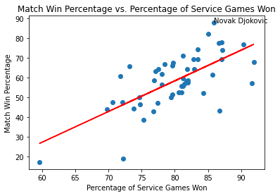

```python
holds = df['Hld%'].to_numpy().reshape((-1,1))

lm = linear_model.LinearRegression()
lm.fit(holds, winPerc)
fig3, ax3, = plt.subplots()

ax3.scatter(holds, winPerc)
ax3.plot(holds, lm.predict(holds), color='red')
ax3.set(xlabel="Percentage of Service Games Won", ylabel="Match Win Percentage", title="Match Win Percentage vs. Percentage of Service Games Won")

novakX = df['Hld%'][0]
plt.text(novakX, novakMWP, "Novak Djokovic")

rSquared = r2_score(winPerc, lm.predict(holds))
slope, intercept, r_value, p_value, std_err = stats.linregress(df['Hld%'].to_numpy(), winPerc)

print("The R squared value is: " +str(rSquared))
print("The p value is: " +str(p_value))
```

```
The R squared value is: 0.4484028191087308
The p value is: 1.0520435541905253e-07
```

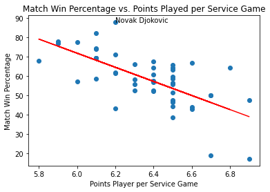

```python
ptsSG = df['Pts/SG'].to_numpy().reshape((-1,1))

lm = linear_model.LinearRegression()
lm.fit(ptsSG, winPerc)
fig3, ax3, = plt.subplots()

ax3.scatter(ptsSG, winPerc)
ax3.plot(ptsSG, lm.predict(ptsSG), color='red')
ax3.set(xlabel="Points Player per Service Game", ylabel="Match Win Percentage", title="Match Win Percentage vs. Points Played per Service Game")

novakX = df['Pts/SG'][0]
plt.text(novakX, novakMWP, "Novak Djokovic")

rSquared = r2_score(winPerc, lm.predict(ptsSG))
slope, intercept, r_value, p_value, std_err = stats.linregress(df['Pts/SG'].to_numpy(), winPerc)

print("The R squared value is: " +str(rSquared))
print("The p value is: " +str(p_value))
```

```
The R squared value is: 0.49338251968395486
The p value is: 1.3069882682558845e-08
```

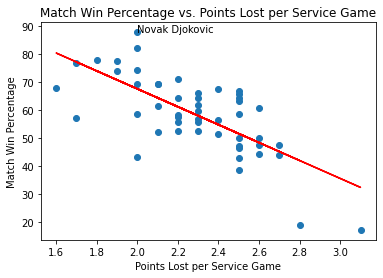

```python
ptsLSG = df['PtsL/SG'].to_numpy().reshape((-1,1))

lm = linear_model.LinearRegression()
lm.fit(ptsLSG, winPerc)
fig3, ax3, = plt.subplots()

ax3.scatter(ptsLSG, winPerc)
ax3.plot(ptsLSG, lm.predict(ptsLSG), color='red')
ax3.set(xlabel="Points Lost per Service Game", ylabel="Match Win Percentage", title="Match Win Percentage vs. Points Lost per Service Game")

novakX = df['PtsL/SG'][0]
plt.text(novakX, novakMWP, "Novak Djokovic")

rSquared = r2_score(winPerc, lm.predict(ptsLSG))
slope, intercept, r_value, p_value, std_err = stats.linregress(df['PtsL/SG'].to_numpy(), winPerc)

print("The R squared value is: " +str(rSquared))
print("The p value is: " +str(p_value))
```

```
The R squared value is: 0.4038015448754756
The p value is: 7.133953454403969e-07
```

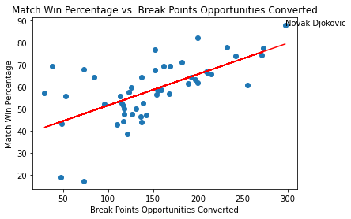

```python
BPConv = df['BPConv'].to_numpy().reshape((-1,1))

lm = linear_model.LinearRegression()
lm.fit(BPConv, winPerc)
fig3, ax3, = plt.subplots()

ax3.scatter(BPConv, winPerc)
ax3.plot(BPConv, lm.predict(BPConv), color='red')
ax3.set(xlabel="Break Points Opportunities Converted", ylabel="Match Win Percentage", title="Match Win Percentage vs. Break Points Opportunities Converted")

novakX = df['BPConv'][0]
plt.text(novakX, novakMWP, "Novak Djokovic")

rSquared = r2_score(winPerc, lm.predict(BPConv))
slope, intercept, r_value, p_value, std_err = stats.linregress(df['BPConv'].to_numpy(), winPerc)

print("The R squared value is: " +str(rSquared))
print("The p value is: " +str(p_value))
```

```
The R squared value is: 0.3673102570095984
The p value is: 3.0990547048740776e-06
```

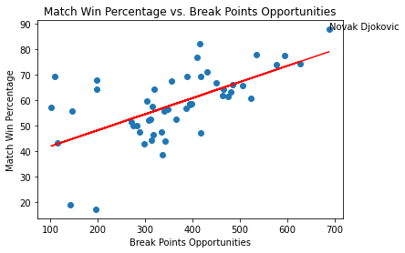

```python
BPChnc = df['BPChnc'].to_numpy().reshape((-1,1))

lm = linear_model.LinearRegression()
lm.fit(BPChnc, winPerc)
fig3, ax3, = plt.subplots()

ax3.scatter(BPChnc, winPerc)
ax3.plot(BPChnc, lm.predict(BPChnc), color='red')
ax3.set(xlabel="Break Points Opportunities", ylabel="Match Win Percentage", title="Match Win Percentage vs. Break Points Opportunities")

novakX = df['BPChnc'][0]
plt.text(novakX, novakMWP, "Novak Djokovic")

rSquared = r2_score(winPerc, lm.predict(BPChnc))
slope, intercept, r_value, p_value, std_err = stats.linregress(df['BPChnc'].to_numpy(), winPerc)

print("The R squared value is: " +str(rSquared))
print("The p value is: " +str(p_value))
```

```
The R squared value is: 0.24557071381550466
The p value is: 0.00025307081436396053
```

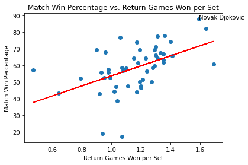

```python
BksServ = df['Bks/S'].to_numpy().reshape((-1,1))

lm = linear_model.LinearRegression()
lm.fit(BksServ, winPerc)
fig3, ax3, = plt.subplots()

ax3.scatter(BksServ, winPerc)
ax3.plot(BksServ, lm.predict(BksServ), color='red')
ax3.set(xlabel="Return Games Won per Set", ylabel="Match Win Percentage", title="Match Win Percentage vs. Return Games Won per Set")

novakX = df['Bks/S'][0]
plt.text(novakX, novakMWP, "Novak Djokovic")

rSquared = r2_score(winPerc, lm.predict(BksServ))
slope, intercept, r_value, p_value, std_err = stats.linregress(df['Bks/S'].to_numpy(), winPerc)

print("The R squared value is: " +str(rSquared))
print("The p value is: " +str(p_value))
```

```
The R squared value is: 0.3135639110093229
The p value is: 2.3548116486531008e-05
```

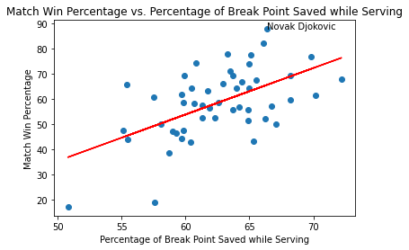

```python
BPSvdP = df['BPSvd%'].to_numpy().reshape((-1,1))

lm = linear_model.LinearRegression()
lm.fit(BPSvdP, winPerc)
fig3, ax3, = plt.subplots()

ax3.scatter(BPSvdP, winPerc)
ax3.plot(BPSvdP, lm.predict(BPSvdP), color='red')
ax3.set(xlabel="Percentage of Break Point Saved while Serving", ylabel="Match Win Percentage", title="Match Win Percentage vs. Percentage of Break Point Saved while Serving")

novakX = df['BPSvd%'][0]
plt.text(novakX, novakMWP, "Novak Djokovic")

rSquared = r2_score(winPerc, lm.predict(BPSvdP))
slope, intercept, r_value, p_value, std_err = stats.linregress(df['BPSvd%'].to_numpy(), winPerc)

print("The R squared value is: " +str(rSquared))
print("The p value is: " +str(p_value))
```

```
The R squared value is: 0.399102841070606
The p value is: 8.659086102737861e-07
```

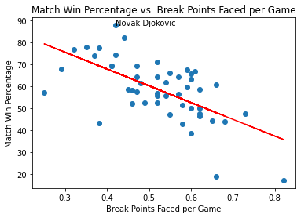

```python
BPvsG = df['BPvs/G'].to_numpy().reshape((-1,1))

lm = linear_model.LinearRegression()
lm.fit(BPvsG, winPerc)
fig3, ax3, = plt.subplots()

ax3.scatter(BPvsG, winPerc)
ax3.plot(BPvsG, lm.predict(BPvsG), color='red')
ax3.set(xlabel="Break Points Faced per Game", ylabel="Match Win Percentage", title="Match Win Percentage vs. Break Points Faced per Game")

novakX = df['BPvs/G'][0]
plt.text(novakX, novakMWP, "Novak Djokovic")

rSquared = r2_score(winPerc, lm.predict(BPvsG))
slope, intercept, r_value, p_value, std_err = stats.linregress(df['BPvs/G'].to_numpy(), winPerc)

print("The R squared value is: " +str(rSquared))
print("The p value is: " +str(p_value))
```

```
The R squared value is: 0.5037449182911656
The p value is: 7.882878123161272e-09
```

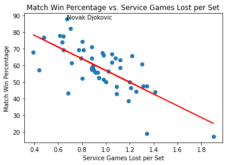

```python
BknpS = df['Bkn/S'].to_numpy().reshape((-1,1))

lm = linear_model.LinearRegression()
lm.fit(BknpS, winPerc)
fig3, ax3, = plt.subplots()

ax3.scatter(BknpS, winPerc)
ax3.plot(BknpS, lm.predict(BknpS), color='red')
ax3.set(xlabel="Service Games Lost per Set", ylabel="Match Win Percentage", title="Match Win Percentage vs. Service Games Lost per Set")

novakX = df['Bkn/S'][0]
plt.text(novakX, novakMWP, "Novak Djokovic")

rSquared = r2_score(winPerc, lm.predict(BknpS))
slope, intercept, r_value, p_value, std_err = stats.linregress(df['Bkn/S'].to_numpy(), winPerc)

print("The R squared value is: " +str(rSquared))
print("The p value is: " +str(p_value))
```

It is evident from the scatter plots with linear regressions that Novak Djokovic excels in a number of various aspects in his game. For every graph, the point representing Djokovic is sitting well above the linear regression line. Additionally for each linear regression the p value is less than 0.001 so we can reject the null hypothesis that each predictor variable is not correlated with match win percentage.

# Exploratory Data Analysis Revisted

To further our analysis of this data we are going to step away from examining Djokovic and look at these predictor variables as a grouping to see if we can create a multiple linear regression in order to predict match win percentage. This takes us back to the Exploratory Data Analysis phase in the Data Science Pipeline. A key aspect of the pipeline is revisiting phases in order to gain new insights on the data. To this point we have created single linear regressions in regards to the correlations between match win percentage and a variety of other variables it is moderate to highly correlated with. These other variables have been treated as independent variables, and we are going to try to see if they are truly independent, which would allow for us to use multiple linear regression to represent match win percentage and the variable it depends on. We will plot another correlation matrix through a seaborn heatmap, this time using the reduced column variables. This will have the same information as the correlation matrix in section 3, but will be more readable and easier to compare all variables in the matrix instead of focusing on a single column. In order to accomplish this, a subset of the tennis dataframe will be created.

```python
dfSubSet = df[['M W%', 'M', 'SPW', '2nd%', 'Hld%', 'Pts/SG', 'PtsL/SG', 'BPConv', 'BPChnc', 'Bks/S', 'BPSvd%', 'BPvs/G', 'Bkn/S']]
dfSubSet.head()
```

|  | M W% | M | SPW | 2nd% | Hld% | Pts/SG | PtsL/SG | BPConv | BPChnc | Bks/S | BPSvd% | BPvs/G | Bkn/S |
| --- | --- | --- | --- | --- | --- | --- | --- | --- | --- | --- | --- | --- | --- |
| 0 | 87.7 | 65 | 67.4 | 53.8 | 85.9 | 6.2 | 2.0 | 297 | 688 | 1.59 | 66.4 | 0.42 | 0.67 |
| 1 | 77.8 | 63 | 68.8 | 52.5 | 87.1 | 5.9 | 1.8 | 232 | 535 | 1.36 | 63.3 | 0.35 | 0.61 |
| 2 | 82.2 | 45 | 66.8 | 56.1 | 85.1 | 6.1 | 2.0 | 200 | 416 | 1.64 | 66.1 | 0.44 | 0.70 |
| 3 | 73.7 | 76 | 68.6 | 57.1 | 87.2 | 6.1 | 1.9 | 242 | 578 | 1.17 | 65.0 | 0.37 | 0.63 |
| 4 | 74.2 | 66 | 67.1 | 48.1 | 83.5 | 6.1 | 2.0 | 271 | 628 | 1.40 | 60.8 | 0.42 | 0.80 |

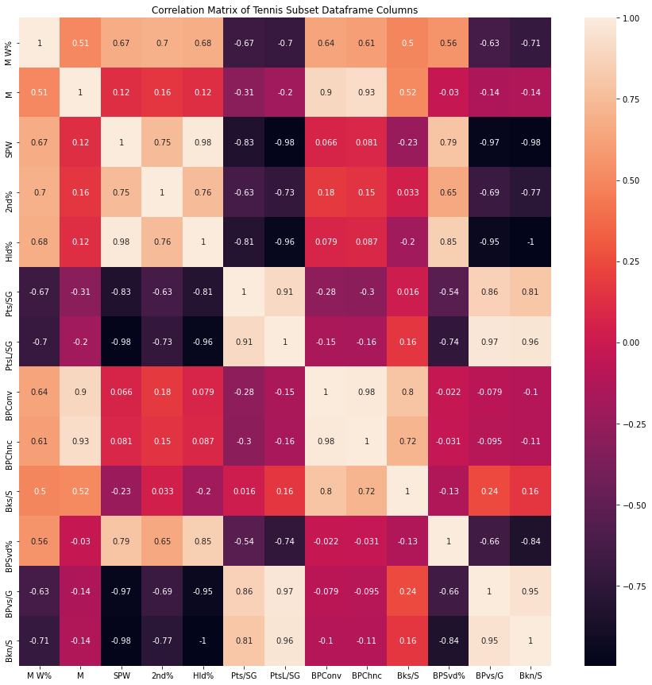

```python
plt.subplots(figsize = (15,15))
hm = sns.heatmap(dfSubSet.corr(), annot = True)
hm.set_title("Correlation Matrix of Tennis Subset Dataframe Columns")
```

When looking at this correlation matrix, it is evident that many of these predictor variables are highly correlated with one another. This makes sense because all of these variables are various aspects of a player's serve and return game, so variables that involve a player's serve are highly correlated as are variables that involve a player's return. This is called multicollinearity and in multiple regression analysis it is important for multicollinearity to not occur, meaning that we only want to include predictors that are not correlated. In our scenario this makes the creation of a multiple linear regression more complicated because of the question of which predictor variables to include. If we include all of these predictor variables, then due to multicollinearity we would have a high standard of error on the coefficients for the multiple linear regression equation.

# Section 5: Communication of Insights Attained

Through visualization of match win percentage against different predictor variables in the form of a scatter plot and linear regression lines we can see that for the 2021 tennis season, Novak Djokovic is performing above average in all aspects of his game. Both in service games and return games, Djokovic is playing at an elite level. During this analysis, we also showed the correlation between match win percentage and different predictor variables.

Tennis has many "games" within the game, and so it is interesting to see which predictor variables had a higher correlation with winning percentage. Here again is the list of predictor variables that were correlated with match win percentage:

M, Matches Played: 0.51  
SPW, Percentage of Service Points Won: 0.67  
2nd%, Second Serve Points Win Percentage: 0.70  
Hld%, Hold Rate, Percentage of Service Games Won: 0.68  
Pts/SG, Points Played per Service Game: -0.67  
PtsL/SG, Points Lost per Service Game: -0.70  
BPConv, Break Points Opportunities Converted: 0.64  
BPChnc, Break Point Chances: 0.61  
Bks/S: Return Games Won per Set: 0.5  
BPSvd%: Percentage of Break Point Saved while Serving: 0.56  
BPvs/G: Break Points Faced per Game: -0.63  
Bkn/S: Service Games Lost per Set: -0.71  
When thinking about each of these predictor variables, it makes logical sense that they are correlated with match win percentage. For instance, it makes sense that winning a higher percentage of service points, SPW, positively correlates with winning more matches. SPW and matching winning percentage had a correlation of 0.67. The interesting point here is insights gained from comparing column variables that were not included in this subset to the ones that were. For instance, the percentage of return points won, RPW, had a weak-moderate correlation of 0.44. Intuitively, we might have thought since winning a high percentage of service points had moderate to almost high correlation with match winning percentage, that winning a high percentage of return points would also have that high correlation with match winning percentage. In tennis, people tend to "hold their serve" or win games in which they are serving, so it is understandable that match win percentage has a higher correlation with percentage of service points won. This also means that people tend to win return games not as frequently, which is shown in the moderately weaker correlation between percentage of service points won and match winning percentage. But here is an interesting insight! When a player is able to string together wins on return points and gain a breakpoint opportunity, it is important for them to capitalize. This is shown by the higher moderate correlation between predictor variable breakpoint opportunities converted and match win percentage of 0.64. This shows a high stress, high importance moment in tennis and is one where, as we saw in the plots, Novak Djokovic excels. Another one, on serve, is second serve points win percent which had a 0.70 correlation with match win percentage. A second serve is usually at a much slower pace than a first serve, in order to avoid a double fault, and therefore gives an opponent a greater opportunity to win a point against your serve. This analysis validates that this is an important point in tennis, as it shows that again Novak Djokovic performs above average in this situation.  
The data obtained unfortunately only included the 2021 tennis season. If more data was available, we could perform the same analysis for multiple years, as well as a standardization to compare players performance across different years. We could also check to see if the predictor variables had the similar correlations to match win percentage across years.